# Diagnostics_HW

Andrey Kravets

2024-11-09

# Чтение данных

Датасет черепно-мозговых травм вследствии падения с электросамоката.

- 1 дюйм – 2.54 см
- 1 кг – 2.2 фунта

```r
data = read_tsv("./trauma_HW.tsv")
summary(data)
```

```
##        id             Name               Sex                 Age
##  Min.   :   1.0   Length:1024        Length:1024        Min.   :18.00
##  1st Qu.: 256.8   Class :character   Class :character   1st Qu.:29.00
##  Median : 512.5   Mode  :character   Mode  :character   Median :41.00
##  Mean   : 512.5                                         Mean   :40.94
##  3rd Qu.: 768.2                                         3rd Qu.:53.00
##  Max.   :1024.0                                         Max.   :64.00
##     Height              Weight          SBP             DBP
##  Length:1024        Min.   : 148   Min.   : 90.0   Min.   : 58.00
##  Class :character   1st Qu.:1748   1st Qu.:106.0   1st Qu.: 78.00
##  Mode  :character   Median :1916   Median :110.0   Median : 84.00
##                     Mean   :1757   Mean   :110.8   Mean   : 84.78
##                     3rd Qu.:2041   3rd Qu.:116.0   3rd Qu.: 90.00
##                     Max.   :2531   Max.   :134.0   Max.   :110.00
##       FOUR             GSC               Hb          Death
##  Min.   : 0.000   Min.   : 3.000   Min.   :  0   Min.   :0.0000
##  1st Qu.: 7.000   1st Qu.: 6.000   1st Qu.:115   1st Qu.:0.0000
##  Median : 9.000   Median : 8.000   Median :128   Median :0.0000
##  Mean   : 8.853   Mean   : 7.785   Mean   :116   Mean   :0.3994
##  3rd Qu.:11.000   3rd Qu.:10.000   3rd Qu.:138   3rd Qu.:1.0000
##  Max.   :16.000   Max.   :14.000   Max.   :162   Max.   :1.0000
```

Мы видим, что у нас проблемы с весом, ростом, уровнем гемоглобина. Для некоторых пациентов “запятая” была съедена и числа превратились из “192,7” в “1927”. Вернемся в эксельку и пофиксим колонки (к сожалению, адекватного и эффектинвного решения через R я не нашёл, а тратить 2 часа на очень странный код не особо хочется).

## Вес, Рост, HB

Что мы сделали:  
1. Вес - Weight_changed=SUBSTITUTE(Weight; “,”; “.”)  
2. Рост - Height_changed=REPLACE(Height; LEN(Height); 1; ““)  
3. HB - HB_changed=SUBSTITUTE(Hb;”,“;”.”) (формулы гугл-шит)

В кратце: заменили запятые на точки, потому что их R воспринимает. В росте убрали ‘“’ дюйма, чтобы спокойно все перевести. Тем самым пофиксили кучу проблем и можем спокойно поанализировать наши данные.

Наши данные:

```r
data_changed = read_tsv("./trauma_changed.tsv")
summary(data_changed)
```

```
##        id             Name               Sex                 Age
##  Min.   :   1.0   Length:1024        Length:1024        Min.   :18.00
##  1st Qu.: 256.8   Class :character   Class :character   1st Qu.:29.00
##  Median : 512.5   Mode  :character   Mode  :character   Median :41.00
##  Mean   : 512.5                                         Mean   :40.94
##  3rd Qu.: 768.2                                         3rd Qu.:53.00
##  Max.   :1024.0                                         Max.   :64.00
##       SBP             DBP              FOUR             GSC
##  Min.   : 90.0   Min.   : 58.00   Min.   : 0.000   Min.   : 3.000
##  1st Qu.:106.0   1st Qu.: 78.00   1st Qu.: 7.000   1st Qu.: 6.000
##  Median :110.0   Median : 84.00   Median : 9.000   Median : 8.000
##  Mean   :110.8   Mean   : 84.78   Mean   : 8.853   Mean   : 7.785
##  3rd Qu.:116.0   3rd Qu.: 90.00   3rd Qu.:11.000   3rd Qu.:10.000
##  Max.   :134.0   Max.   :110.00   Max.   :16.000   Max.   :14.000
##      Death        Height_changed  Weight_changed    HB_changed
##  Min.   :0.0000   Min.   :63.80   Min.   :133.3   Min.   : 0.0
##  1st Qu.:0.0000   1st Qu.:69.70   1st Qu.:181.7   1st Qu.:12.0
##  Median :0.0000   Median :72.80   Median :193.9   Median :13.1
##  Mean   :0.3994   Mean   :72.42   Mean   :193.5   Mean   :12.8
##  3rd Qu.:1.0000   3rd Qu.:75.10   3rd Qu.:205.4   3rd Qu.:14.0
##  Max.   :1.0000   Max.   :79.90   Max.   :253.1   Max.   :16.2
```

## Переводы

Переводим вес, рост в [НОРМАЛЬНЫЕ шкалы](https://www.youtube.com/watch?v=Y-3IV11_ZgA&ab_channel=AltraNade) :)

```r
data_changed = data_changed %>% mutate(Height_meter = Height_changed*2.54/100, Weight_kg=Weight_changed/2.2)
summary(data_changed)
```

```
##        id             Name               Sex                 Age
##  Min.   :   1.0   Length:1024        Length:1024        Min.   :18.00
##  1st Qu.: 256.8   Class :character   Class :character   1st Qu.:29.00
##  Median : 512.5   Mode  :character   Mode  :character   Median :41.00
##  Mean   : 512.5                                         Mean   :40.94
##  3rd Qu.: 768.2                                         3rd Qu.:53.00
##  Max.   :1024.0                                         Max.   :64.00
##       SBP             DBP              FOUR             GSC
##  Min.   : 90.0   Min.   : 58.00   Min.   : 0.000   Min.   : 3.000
##  1st Qu.:106.0   1st Qu.: 78.00   1st Qu.: 7.000   1st Qu.: 6.000
##  Median :110.0   Median : 84.00   Median : 9.000   Median : 8.000
##  Mean   :110.8   Mean   : 84.78   Mean   : 8.853   Mean   : 7.785
##  3rd Qu.:116.0   3rd Qu.: 90.00   3rd Qu.:11.000   3rd Qu.:10.000
##  Max.   :134.0   Max.   :110.00   Max.   :16.000   Max.   :14.000
##      Death        Height_changed  Weight_changed    HB_changed
##  Min.   :0.0000   Min.   :63.80   Min.   :133.3   Min.   : 0.0
##  1st Qu.:0.0000   1st Qu.:69.70   1st Qu.:181.7   1st Qu.:12.0
##  Median :0.0000   Median :72.80   Median :193.9   Median :13.1
##  Mean   :0.3994   Mean   :72.42   Mean   :193.5   Mean   :12.8
##  3rd Qu.:1.0000   3rd Qu.:75.10   3rd Qu.:205.4   3rd Qu.:14.0
##  Max.   :1.0000   Max.   :79.90   Max.   :253.1   Max.   :16.2
##   Height_meter     Weight_kg
##  Min.   :1.621   Min.   : 60.59
##  1st Qu.:1.770   1st Qu.: 82.58
##  Median :1.849   Median : 88.14
##  Mean   :1.840   Mean   : 87.97
##  3rd Qu.:1.908   3rd Qu.: 93.38
##  Max.   :2.029   Max.   :115.05
```

Еще заметим, что у нас в колонке HB_changed есть образцы с уровнем 0, что, скорее всего, является None. Заменим:

```r
data_changed = data_changed %>% mutate(HB_changed = case_when(HB_changed < 8. ~ NaN, HB_changed > 8. ~ HB_changed))
```

Посмотрим на пол ещё (тут все ок) и заменим на категории:

```r
unique_values_each <- data_changed %>%
  select(where(is.character) | where(is.factor)) %>%
  summarise_all(~ list(unique(.)))
#unique_values_each
print(unique_values_each %>% pull(Sex))
```

```
## [[1]]
## [1] "Female" "Male"
```

```r
data_changed = data_changed %>% mutate(Sex = factor(Sex))
```

Возьмём финальные колонки и пойдем дальше:

```r
data_final <- data_changed %>%
  select(id, Name, Sex, HB_changed, Height_meter, Weight_kg, Age, SBP, DBP, FOUR, GSC, Death)

summary(data_final)
```

```
##        id             Name               Sex        HB_changed
##  Min.   :   1.0   Length:1024        Female:384   Min.   : 9.40
##  1st Qu.: 256.8   Class :character   Male  :640   1st Qu.:12.10
##  Median : 512.5   Mode  :character                Median :13.10
##  Mean   : 512.5                                   Mean   :13.01
##  3rd Qu.: 768.2                                   3rd Qu.:14.00
##  Max.   :1024.0                                   Max.   :16.20
##                                                   NA's   :16
##   Height_meter     Weight_kg           Age             SBP
##  Min.   :1.621   Min.   : 60.59   Min.   :18.00   Min.   : 90.0
##  1st Qu.:1.770   1st Qu.: 82.58   1st Qu.:29.00   1st Qu.:106.0
##  Median :1.849   Median : 88.14   Median :41.00   Median :110.0
##  Mean   :1.840   Mean   : 87.97   Mean   :40.94   Mean   :110.8
##  3rd Qu.:1.908   3rd Qu.: 93.38   3rd Qu.:53.00   3rd Qu.:116.0
##  Max.   :2.029   Max.   :115.05   Max.   :64.00   Max.   :134.0
##
##       DBP              FOUR             GSC             Death
##  Min.   : 58.00   Min.   : 0.000   Min.   : 3.000   Min.   :0.0000
##  1st Qu.: 78.00   1st Qu.: 7.000   1st Qu.: 6.000   1st Qu.:0.0000
##  Median : 84.00   Median : 9.000   Median : 8.000   Median :0.0000
##  Mean   : 84.78   Mean   : 8.853   Mean   : 7.785   Mean   :0.3994
##  3rd Qu.: 90.00   3rd Qu.:11.000   3rd Qu.:10.000   3rd Qu.:1.0000
##  Max.   :110.00   Max.   :16.000   Max.   :14.000   Max.   :1.0000
##
```

```r
# Смотрим NA в каждой из колонок
data_final %>%
  summarise(across(everything(), ~ sum(is.na(.)), .names = "na_{.col}"))
```

```
## # A tibble: 1 × 12
##   na_id na_Name na_Sex na_HB_changed na_Height_meter na_Weight_kg na_Age na_SBP
##   <int>   <int>  <int>         <int>           <int>        <int>  <int>  <int>
## 1     0       0      0            16               0            0      0      0
## # ℹ 4 more variables: na_DBP <int>, na_FOUR <int>, na_GSC <int>, na_Death <int>
```

# Задания

```r
summary(data_final)
```

```
##        id             Name               Sex        HB_changed
##  Min.   :   1.0   Length:1024        Female:384   Min.   : 9.40
##  1st Qu.: 256.8   Class :character   Male  :640   1st Qu.:12.10
##  Median : 512.5   Mode  :character                Median :13.10
##  Mean   : 512.5                                   Mean   :13.01
##  3rd Qu.: 768.2                                   3rd Qu.:14.00
##  Max.   :1024.0                                   Max.   :16.20
##                                                   NA's   :16
##   Height_meter     Weight_kg           Age             SBP
##  Min.   :1.621   Min.   : 60.59   Min.   :18.00   Min.   : 90.0
##  1st Qu.:1.770   1st Qu.: 82.58   1st Qu.:29.00   1st Qu.:106.0
##  Median :1.849   Median : 88.14   Median :41.00   Median :110.0
##  Mean   :1.840   Mean   : 87.97   Mean   :40.94   Mean   :110.8
##  3rd Qu.:1.908   3rd Qu.: 93.38   3rd Qu.:53.00   3rd Qu.:116.0
##  Max.   :2.029   Max.   :115.05   Max.   :64.00   Max.   :134.0
##
##       DBP              FOUR             GSC             Death
##  Min.   : 58.00   Min.   : 0.000   Min.   : 3.000   Min.   :0.0000
##  1st Qu.: 78.00   1st Qu.: 7.000   1st Qu.: 6.000   1st Qu.:0.0000
##  Median : 84.00   Median : 9.000   Median : 8.000   Median :0.0000
##  Mean   : 84.78   Mean   : 8.853   Mean   : 7.785   Mean   :0.3994
##  3rd Qu.: 90.00   3rd Qu.:11.000   3rd Qu.:10.000   3rd Qu.:1.0000
##  Max.   :110.00   Max.   :16.000   Max.   :14.000   Max.   :1.0000
##
```

## Задание 1. Дайте описательную статистику для переменных, включённых в датасет. Дополнительно рассчитайте, у какого количества пациентов и в каком проценте случаев у пациентов был снижен уровень гемоглобина? Используйте следующие референтные значения (Мужчины: 13.5–16 г/дл, Женщины: 12–14 г/дл).

```r
data_final <- data_final %>% mutate(HB_level = factor(case_when((Sex=="Male") & (HB_changed < 13.5) ~ "Low", (Sex=='Female') & (HB_changed < 12.0) ~ "Low", TRUE~"Normal")))
# Пациенты с неизвестным HB попадут в группу "Normal"

data_final %>%
  select(Sex, HB_level, HB_changed) %>%
  group_by(Sex, HB_level) %>%
  summarise(count = n(), .groups = 'drop') %>%
  group_by(Sex) %>%
  mutate(total = sum(count)) %>%
  ungroup() %>%
  mutate(percent = (count / total) * 100)
```

```
## # A tibble: 4 × 5
##   Sex    HB_level count total percent
##   <fct>  <fct>    <int> <int>   <dbl>
## 1 Female Low        226   384    58.9
## 2 Female Normal     158   384    41.1
## 3 Male   Low        232   640    36.2
## 4 Male   Normal     408   640    63.7
```

```r
data_final %>%
  select(Death, HB_level, HB_changed) %>%
  group_by(Death, HB_level) %>%
  summarise(count = n(), .groups = 'drop') %>%
  group_by(Death) %>%
  mutate(total = sum(count)) %>%
  ungroup() %>%
  mutate(percent = (count / total) * 100)
```

```
## # A tibble: 4 × 5
##   Death HB_level count total percent
##   <dbl> <fct>    <int> <int>   <dbl>
## 1     0 Low        166   615    27.0
## 2     0 Normal     449   615    73.0
## 3     1 Low        292   409    71.4
## 4     1 Normal     117   409    28.6
```

## Задание 2. Рассчитайте индекс массы тела у пациентов (кг / м2). Каков был средний (M (SD)) уровень ИМТ у пациентов, включённых в исследование? Какая доля пациентов имела ожирение (ИМТ > 30)?

```r
data_final %>%
  mutate(BMI = round(Weight_kg / (Height_meter ^ 2), 2)) %>%
  mutate(BMI_high = if_else(BMI > 30, "High", "Low")) %>%
  summarise(
    Mean_BMI = mean(BMI, na.rm = TRUE),                  # Средний ИМТ
    SD_BMI = sd(BMI, na.rm = TRUE),                      # Стандартное отклонение ИМТ
    Obesity_Count = sum(BMI > 30, na.rm = TRUE),         # Количество пациентов с ожирением
    Obesity_Percent = (Obesity_Count / n()) * 100        # Процент пациентов с ожирением
  ) %>%
  mutate(Mean_SD_BMI = paste0(round(Mean_BMI, 2), " (", round(SD_BMI, 2), ")")) %>%
  select(Mean_SD_BMI, Obesity_Count, Obesity_Percent)
```

```
## # A tibble: 1 × 3
##   Mean_SD_BMI  Obesity_Count Obesity_Percent
##   <chr>                <int>           <dbl>
## 1 26.06 (2.57)            71            6.93
```

## Задание 3. Как выглядит ROC-кривая для предсказания летального исхода в течение 24 часов по переменной, характеризующей уровень гемоглобина? Постройте график. Чем может быть обусловлена такая форма кривой?

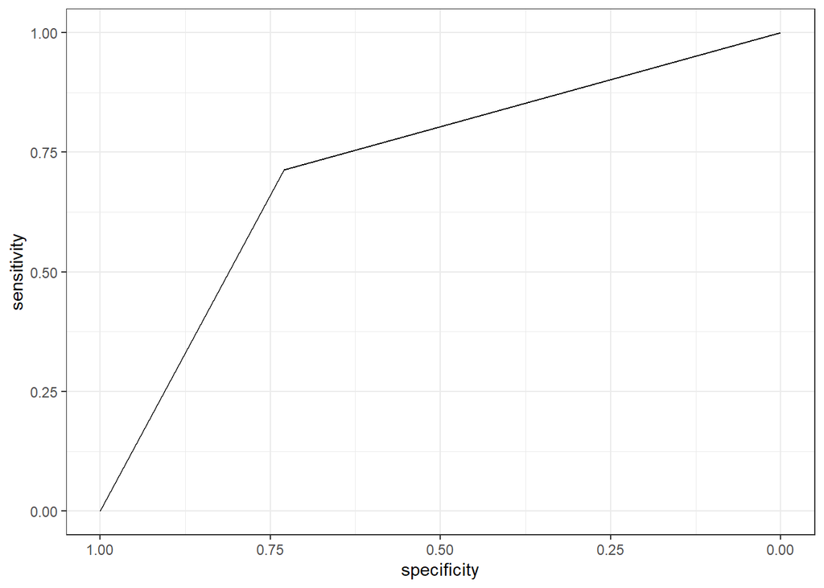

```r
data_roc = data_final %>% mutate(HB_level_normal = if_else(HB_level == 'Normal', 1, 0))
roc_curve_HB <- roc(Death ~ HB_level_normal,
                   data = data_roc)
roc_curve_HB %>% ggroc() + theme_bw()
```

Т.к. мы разделили пациентов по уровню ГБ на две части: “Нормальный уровнень” и “Низкий уровень”, то для по уровню HB у нас можем быть три трешхолда: T=0, 0<T<1 (неважно какое число, главное, что между 0 и 1, т.к. все значения в нашей таблице будут либо больше трешхолда, либо меньше (у нас только 0 и 1 в таблице)), T=1. Отсюда легко понять, что при T=0 и T=1 у нас будет Sensitivity = 100/0 и Specificity=0,100 соответственно. При 0<T<1 будет предсказательная сила равна проценту кейсов, у которых HB_level_normal = 0 & Death = 1.

```r
data_roc = data_final %>% mutate(HB_level_normal = if_else(HB_level == 'Normal', 1, 0))
roc_curve_HB <- roc(Death ~ HB_level_normal,
                   data = data_roc, ci=T)
roc_curve_HB
```

```
##
## Call:
## roc.formula(formula = Death ~ HB_level_normal, data = data_roc,     ci = T)
##
## Data: HB_level_normal in 615 controls (Death 0) > 409 cases (Death 1).
## Area under the curve: 0.722
## 95% CI: 0.6939-0.7501 (DeLong)
```

“Area under the curve: 0.722 95% CI: 0.6939-0.7501 (DeLong)”

## Задание 5. Проведите ROC-анализ и определите, какое пороговое значение является оптимальным для предсказания летального исхода в течение 24 часов по шкале комы Глазго. Какой чувствительностью и специфичностью обладает данный порог?

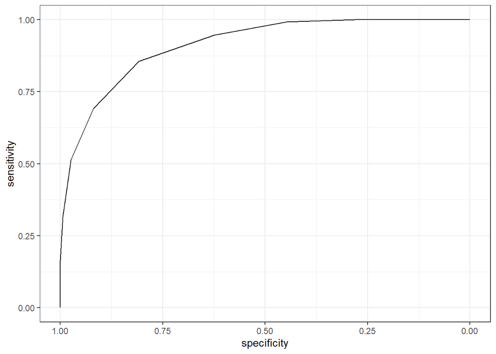

```r
data_roc = data_final
roc_curve_GSC <- roc(Death ~ GSC,
                   data = data_roc, ci=T)
roc_curve_GSC %>% ggroc() + theme_bw()
```

```r
optimal_threshold <- coords(roc_curve_GSC, "best", ret = "threshold", best.method = "youden")

optimal_metrics <- coords(roc_curve_GSC, x = optimal_threshold$threshold,
                          input = "threshold", ret = c("sensitivity", "specificity"))

print(list(
  Threshold = optimal_threshold,
  Sensitivity = optimal_metrics["sensitivity"],
  Specificity = optimal_metrics["specificity"]
))
```

```
## $Threshold
##   threshold
## 1       7.5
##
## $Sensitivity
##   sensitivity
## 1   0.8557457
##
## $Specificity
##   specificity
## 1   0.8081301
```

Расчитали лучший трешхолд по “индексу Юдена” = 7.5. Se=86%, Sp=81%

## Задание 6. Какая из количественных переменных в датасете (включая рассчитанный вами ранее ИМТ) обладает наибольшей площадью под ROC-кривой? Как вы можете интерпретировать это знание? Какая количественная переменная имеет наименьшую площадь?

Смотрим на количественные переменные:

```r
result
```

```
## # A tibble: 9 × 4
##   name           AUC AUC_LCL AUC_UCL
##   <chr>        <dbl>   <dbl>   <dbl>
## 1 Age          0.527   0.491   0.563
## 2 BMI          0.498   0.462   0.535
## 3 DBP          0.744   0.714   0.774
## 4 FOUR         0.934   0.92    0.948
## 5 GSC          0.912   0.896   0.929
## 6 HB_changed   0.708   0.676   0.739
## 7 Height_meter 0.482   0.445   0.518
## 8 SBP          0.786   0.759   0.814
## 9 Weight_kg    0.518   0.482   0.554
```

Видим, что для переменных, таких как Возраст, ИМТ (рост+вес), AUC ~ 0.5. Что значит, что эти переменные не имеют предиктивной силы для предсказания исхода.

Переменные со “средней силой”: DBP, SBP - информация по давлению даёт примерно AUC~0.75, это нам говорит о том, что давление все-таки связано с исходом и что дополнительный ресерч может быть проведен здесь. Например, анализ статуса гипер и гипотензии.

Наибольший AUC имеет переменная FOUR (сразу же за ней идёт GSC) - балл по шкале комы FOUR при поступлении. Давайте глянем на ROC-AUC этой переменной:

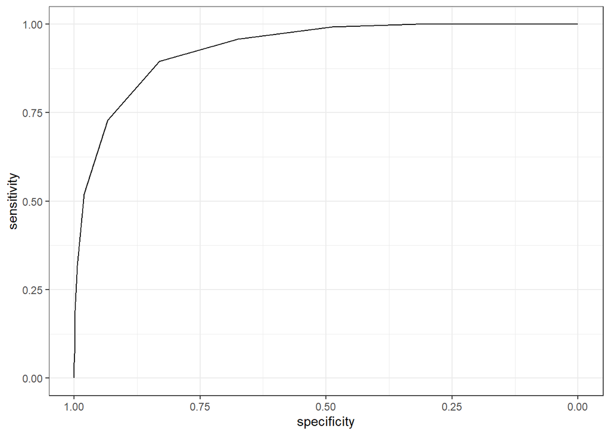

```r
data_roc = data_final
roc_curve_FOUR <- roc(Death ~ FOUR,
                   data = data_roc, ci=T)
roc_curve_FOUR %>% ggroc() + theme_bw()
```

Предпологаю, что FOUR и GSC скореллированы, это обсулавливает схожие результаты по ROC-AUC, давайте напоследок построим спирмена для них:

```r
spearman_corr <- cor(data_final$GSC, data_final$FOUR, method = "spearman")

# Print result
print(spearman_corr)
```

```
## [1] 0.9421632
```

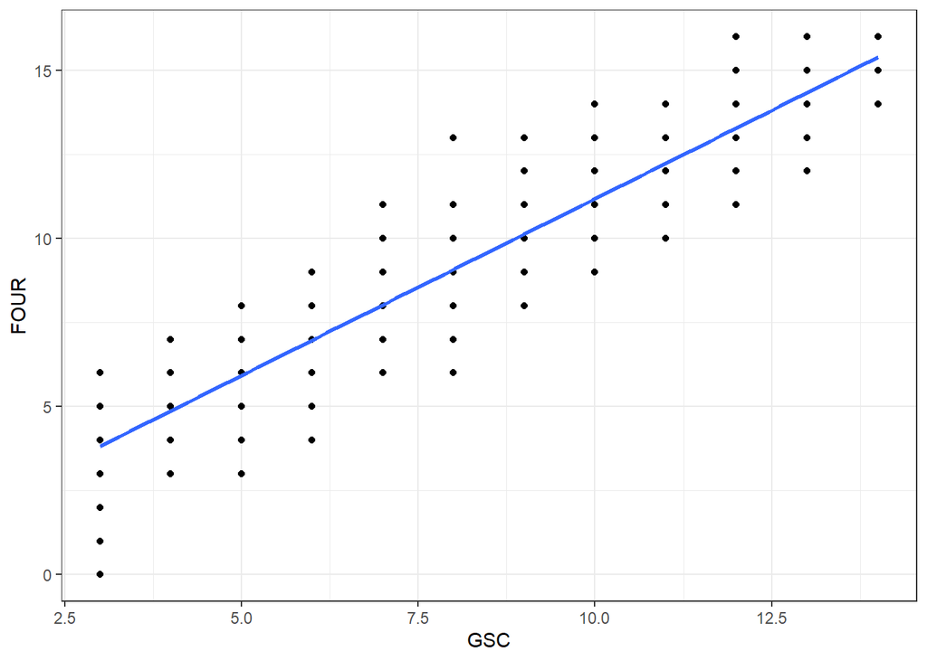

```r
data_final %>%  ggplot(aes(x = GSC,
                 y = FOUR))+
  geom_point()+
  geom_smooth(se = FALSE,
              method = "lm")+
  theme_bw()
```

Spearman ro = 0.94 !